# The ABC-XYZ of Data Science

### **Install Packages**

```r
install.packages("rvest","stringr","dplyr","plyr","ggplot2","tidyr","caret","scales","gridExtra")
```

### **Load Libraries**

```r
library(rvest)
library(stringr)
library(dplyr)
library(plyr)
library(ggplot2)
library(tidyr)
library(caret)
library(scales)
library(gridExtra)
```

### **A website with holiday data is: timeanddate.com**

```r
url <- "https://www.timeanddate.com/holidays/"
```

### **Great, so how do we get the holidays for each country?**

Two options: Either we use the countries names to make the URLs or we know all the URLs for each countries

```r
links <- url %>%
 read_html %>%
 html_nodes(".main-content-div .row a") %>%
 html_attr("href")
```

### **Let’s inspect what we have gotten**

```r
head(links)
```

```
[1] "/"
[2] "/calendar/"
[3] "/holidays/anguilla/"
[4] "/holidays/antigua-and-barbuda/"
[5] "/holidays/aruba/"
[6] "/holidays/barbados/"
```

```r
paste("")
```

```
[1] ""
```

```r
tail(links)
```

```
[1] "/holidays/tanzania/" "/holidays/togo/"
[3] "/holidays/tunisia/"  "/holidays/uganda/"
[5] "/holidays/zambia/"   "/holidays/zimbabwe/"
```

### **We got the paths from the base URL and it also seems that the first two links are not country related so let’s take it out**

```r
links <- links [3:length(links)]
links
```

```
  [1] "/holidays/anguilla/"
  [2] "/holidays/antigua-and-barbuda/"
  [3] "/holidays/aruba/"
  [4] "/holidays/barbados/"
  [5] "/holidays/belize/"
  [6] "/holidays/british-virgin-islands/"
  [7] "/holidays/canada/"
  [8] "/holidays/cayman-islands/"
  [9] "/holidays/costa-rica/"
 [10] "/holidays/cuba/"
 [11] "/holidays/curacao/"
 [12] "/holidays/dominica/"
 [13] "/holidays/dominican-republic/"
 [14] "/holidays/el-salvador/"
 [15] "/holidays/grenada/"
```

[output cut: 215 more lines]

### **Let’s append the base URL to each path**

```r
links <- paste0("https://www.timeanddate.com",links)
links[1:10]
```

```
 [1] "https://www.timeanddate.com/holidays/anguilla/"
 [2] "https://www.timeanddate.com/holidays/antigua-and-barbuda/"
 [3] "https://www.timeanddate.com/holidays/aruba/"
 [4] "https://www.timeanddate.com/holidays/barbados/"
 [5] "https://www.timeanddate.com/holidays/belize/"
 [6] "https://www.timeanddate.com/holidays/british-virgin-islands/"
 [7] "https://www.timeanddate.com/holidays/canada/"
 [8] "https://www.timeanddate.com/holidays/cayman-islands/"
 [9] "https://www.timeanddate.com/holidays/costa-rica/"
[10] "https://www.timeanddate.com/holidays/cuba/"
```

### **Let’s extract the actual country names from the links using stringr and** [regex](https://www.rstudio.com/wp-content/uploads/2016/09/RegExCheatsheet.pdf)

```r
country <- stringr::str_replace_all(links,"https://www.timeanddate.com/holidays/","") %>%
str_replace_all(.,"[-/]"," ") %>%
  stringr::str_trim()
country[1:10]
```

```
 [1] "anguilla"               "antigua and barbuda"
 [3] "aruba"                  "barbados"
 [5] "belize"                 "british virgin islands"
 [7] "canada"                 "cayman islands"
 [9] "costa rica"             "cuba"
```

### **Change from lower case to Title Case**

```r
country =stringr::str_to_title(country)
country[1:10]
```

```
 [1] "Anguilla"               "Antigua And Barbuda"
 [3] "Aruba"                  "Barbados"
 [5] "Belize"                 "British Virgin Islands"
 [7] "Canada"                 "Cayman Islands"
 [9] "Costa Rica"             "Cuba"
```

### **We are going to write our own function to extract the number of holidays for each country using the holiday_per_country function below**

```r
holiday_per_country = function(index){
  require(rvest)
  require(dplyr)
holidays=try(links[index] %>%
                      read_html %>%
                      html_node(".zebra") %>%
                      html_table %>%
                       dplyr::filter((grepl(pattern = "Holiday",`Holiday Type`,ignore.case= T)==T))
                     ,silent = T)
  if(is.list(holidays)){
    return(c(country[index],nrow(holidays)-1))
  }
  else{
    return(c(country[index],0))
  }
}
```

### **Now, we will apply this function to each of links we have our a dataset**

```r
################DO NOT RUN#######################
holiday_df=plyr::ldply(1:length(links),holiday_per_country)
names(holiday_df) = c("Country","no_of_holidays")
################DO NOT RUN#######################
```

```r
holiday_df = read.csv("holiday_df.csv")
holiday_df %>% dplyr::as_tibble()
```

| Country | no_of_holidays |
| --- | --- |
| Anguilla | 12 |
| Antigua And Barbuda | 12 |
| Aruba | 10 |
| Barbados | 13 |
| Belize | 14 |
| British Virgin Islands | 14 |
| Canada | 55 |
| Cayman Islands | 13 |
| Costa Rica | 9 |
| Cuba | 10 |

[output cut: 220 more lines]

### **We would use ggplot2 to inspect our data. For more info on how to use ggplot2, check out the** [ggplot2 Cheatseet](https://www.rstudio.com/wp-content/uploads/2015/03/ggplot2-cheatsheet.pdf)

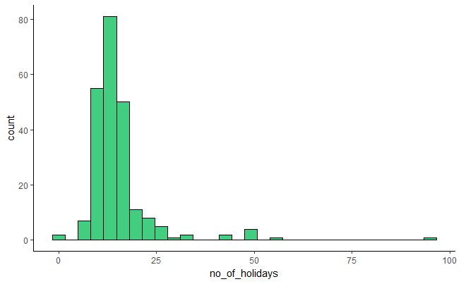

```r
holiday_df$no_of_holidays = as.numeric(holiday_df$no_of_holidays)
ggplot(holiday_df,aes(no_of_holidays))+
  geom_histogram(fill="seagreen3",color="black")+
  theme_classic()
```

### **Let’s find out the exact countries that are the top outliers**

```r
holiday_df %>%
  arrange(-no_of_holidays)
```

| Country | no_of_holidays |
| --- | --- |
| Us | 95 |
| Canada | 55 |
| Bangladesh | 50 |
| India | 50 |
| Spain | 50 |
| Australia | 48 |
| Pakistan | 41 |
| Uk | 41 |
| Malaysia | 34 |
| Sri Lanka | 32 |

[output cut: 220 more lines]

### **Interesting, let’s take a look at The** [US](https://www.timeanddate.com/holidays/us/)

You would see that a lot of their holidays are either State or County-observed. Do these types of holidays count if you are looking at the nation as a whole?

```r
 local_holidays = function(index) {
   column_names=names(links[index] %>%
                                        read_html %>%
                                        html_node(".zebra") %>%
                                        html_table) %>% str_to_lower()
   if("where it is observed" %in%column_names  == T){
     country[index]
   }

 }
#We have two options of using this function
#Option 1: A for loop.
#Pros: Ability to save intermediary result & Ability to create custom progress trackers
#Cons: Significantly slower & Code is less concise
# local_countries=NULL
# for (i in 1:length(links)){
#   ind=local_holidays(i)
#   local_countries=append(local_countries,ind)
#   print(i/length(links))
# }
#Option 2: Vectorization using the lapply function
#Pros: Fast & Concise code
#Cons: Intermediary results are not saved & No custom progress function although some progressbar functionalities can be used with it
local_countries=lapply(1:length(links),local_holidays) %>% unlist
```

```
closing unused connection 3 (https://www.timeanddate.com/holidays/anguilla/)
```

```r
################DO NOT RUN#######################
local_countries=NULL
for (i in 1:length(links)){
  ind=local_holidays(i)
  local_countries=append(local_countries,ind)
  print(i/length(links))
}

#Option 2: Vectorization using the lapply function
#Pros: Fast & Concise code
#Cons: Intermediary results are not saved & No custom progress function although some progressbar functionalities can be used with it
local_countries=lapply(1:length(links),local_holidays) %>% unlist
################DO NOT RUN#######################
```

```r
local_countries=c("Canada","Us","Australia","Indonesia","Philippines","United Arab Emirates","Germany","Spain","Switzerland","Uk")
```

### **Let’s take a look at the countries that have these local holidays**

```r
paste("The Number of Countries with local holidays:",length(local_countries))
```

```
[1] "The Number of Countries with local holidays: 10"
```

```r
local_countries
```

```
 [1] "Canada"               "Us"
 [3] "Australia"            "Indonesia"
 [5] "Philippines"          "United Arab Emirates"
 [7] "Germany"              "Spain"
 [9] "Switzerland"          "Uk"
```

### **Let’s get the number of national holidays for these countries**

```r
#Extract the index numbers for each of these countries
indices = which(country %in% local_countries)
updated_holidays= function (index){

table=links[index] %>%
                read_html %>%
                html_node(".zebra") %>%
                html_table
names(table)=names(table) %>%
  str_to_lower()
updated_table = table %>%
  filter( (grepl('holiday',`holiday type`,ignore.case =T) &
             `where it is observed` == "" & grepl('jewish|Hindu',`holiday type`,ignore.case =T)==F) | grepl('all',`where it is observed`,ignore.case =T))
  return(c(country[index],nrow(updated_table)))
}
new_holiday = ldply(indices,updated_holidays)
names(new_holiday)=c("Country","no_of_holidays")
new_holiday=cbind(new_holiday,indices)
new_holiday
```

| Country | no_of_holidays | indices |
| --- | --- | --- |
| Canada | 10 | 7 |
| Us | 14 | 36 |
| Australia | 11 | 55 |
| Indonesia | 16 | 85 |
| Philippines | 23 | 104 |
| United Arab Emirates | 14 | 117 |
| Germany | 10 | 139 |
| Spain | 10 | 170 |
| Switzerland | 10 | 172 |
| Uk | 8 | 175 |

### **Now, let’s replace the old holiday values with the new ones**

```r
for(i in indices){
holiday_df$no_of_holidays[i]=new_holiday$no_of_holidays[new_holiday$indices==i]

}
holiday_df=holiday_df %>%
  mutate(no_of_holidays=as.numeric(no_of_holidays))
holiday_df%>%
  filter(Country == "Canada") %>%
  as_tibble()
```

| Country | no_of_holidays |
| --- | --- |
| Canada | 10 |

### **Let’s check what we have left as outliers**

```r
holiday_df %>%
  arrange(-no_of_holidays)
```

| Country | no_of_holidays |
| --- | --- |
| Bangladesh | 50 |
| India | 50 |
| Pakistan | 41 |
| Malaysia | 34 |
| Sri Lanka | 32 |
| Nepal | 28 |
| China | 27 |
| Iran | 26 |
| Macedonia | 26 |
| Cambodia | 25 |

[output cut: 220 more lines]

### **Update actual holidays for the top 4 outliers**

```r
holiday_df$no_of_holidays[holiday_df$Country=="Bangladesh"]=21
holiday_df$no_of_holidays[holiday_df$Country=="India"]=18
holiday_df$no_of_holidays[holiday_df$Country=="Pakistan"]=20
holiday_df$no_of_holidays[holiday_df$Country=="Malaysia"]=20
```

### **Inspect again using our Histogram from before**

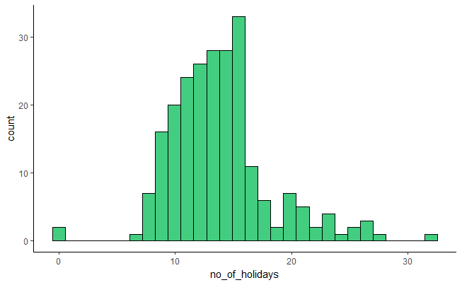

```r
ggplot(holiday_df,aes(no_of_holidays))+
  geom_histogram(fill="seagreen3",color="black")+
  theme_classic()
```

### **Let’s check out those zeros**

```r
holiday_df %>%
  arrange(no_of_holidays)
```

| Country | no_of_holidays |
| --- | --- |
| Un | 0 |
| World | 0 |
| Djibouti | 7 |
| Falkland Islands | 8 |
| Nauru | 8 |
| Mongolia | 8 |
| Uk | 8 |
| Mauritania | 8 |
| Sao Tome And Principe | 8 |
| Sudan | 8 |

[output cut: 220 more lines]

### **Those are not countries so we will take them out**

```r
holiday_df=holiday_df %>%
  filter(no_of_holidays>0)
```

### **Let’s also make sure that there no duplicates**

```r
holiday_df %>%
  group_by(Country) %>%
  dplyr::summarise(no_of_occurences=n()) %>%
  arrange(-no_of_occurences)
```

| Country | no_of_occurences |
| --- | --- |
| British Virgin Islands | 2 |
| Cyprus | 2 |
| Georgia | 2 |
| Russia | 2 |
| Turkey | 2 |
| Afghanistan | 1 |
| Albania | 1 |
| Algeria | 1 |
| Andorra | 1 |
| Angola | 1 |

[output cut: 213 more lines]

### **Let’s investigate Russia**

```r
holiday_df %>%
  filter(Country=="Russia")
```

| Country | no_of_holidays |
| --- | --- |
| Russia | 18 |
| Russia | 18 |

### **We would remove them using the distinct() function from dplyr**

```r
holiday_df=holiday_df %>%
  distinct(Country,no_of_holidays)
```

### **Let’s check the dataframe after we have removed the duplicates**

```r
 holiday_df %>%
  group_by(Country) %>%
  dplyr::summarise(no_of_occurences=n()) %>%
  arrange(-no_of_occurences)
```

| Country | no_of_occurences |
| --- | --- |
| Afghanistan | 1 |
| Albania | 1 |
| Algeria | 1 |
| Andorra | 1 |
| Angola | 1 |
| Anguilla | 1 |
| Antigua And Barbuda | 1 |
| Argentina | 1 |
| Armenia | 1 |
| Aruba | 1 |

[output cut: 213 more lines]

### **Let’s look at a visual map of holidays in each country on a** [Tableau Dashboard](https://public.tableau.com/profile/rosebud.anwuri#!/vizhome/TheABC-XYZofDataScience/Sheet1?publish=yes)

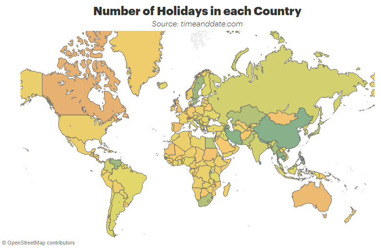

### **Now, let’s look at Life Expectancy data from The World Bank**

```r
life_expectancy_df = read.csv("Life Expectancy.csv")
life_expectancy_df
```

| Country.Name | Country.Code | X2008..YR2008. | X2009..YR2009. | X2010..YR2010. | X2011..YR2011. | X2012..YR2012. | X2013..YR2013. | X2014..YR2014. | X2015..YR2015. |
| --- | --- | --- | --- | --- | --- | --- | --- | --- | --- |
| Afghanistan | AFG | 60.25673171 | 60.76460976 | 61.23546341 | 61.6742439 | 62.09297561 | 62.50160976 | 62.90268293 | 63.29819512 |
| Albania | ALB | 76.07265854 | 76.39487805 | 76.74790244 | 77.10846341 | 77.44826829 | 77.74709756 | 77.99839024 | 78.20314634 |
| Algeria | DZA | 74.02531707 | 74.36785366 | 74.66978049 | 74.93756098 | 75.18119512 | 75.41217073 | 75.63502439 | 75.85529268 |
| American Samoa | ASM | .. | .. | .. | .. | .. | .. | .. | .. |
| Andorra | AND | .. | .. | .. | .. | .. | .. | .. | .. |
| Angola | AGO | 56.13929268 | 57.181 | 58.14112195 | 58.9912439 | 59.71843902 | 60.3217561 | 60.80673171 | 61.18934146 |
| Antigua And Barbuda | ATG | 74.98219512 | 75.15153659 | 75.31329268 | 75.46953659 | 75.62180488 | 75.77365854 | 75.92409756 | 76.07563415 |
| Argentina | ARG | 75.17129268 | 75.33109756 | 75.49202439 | 75.65356098 | 75.8147561 | 75.97456098 | 76.134 | 76.29302439 |
| Armenia | ARM | 72.72590244 | 72.8987561 | 73.10929268 | 73.34597561 | 73.58621951 | 73.81192683 | 74.01958537 | 74.20619512 |
| Aruba | ABW | 74.62768293 | 74.77114634 | 74.91063415 | 75.04765854 | 75.18319512 | 75.31973171 | 75.45678049 | 75.59434146 |

[output cut: 208 more lines]

### **Using tidyr’s gather() function we would collapse all these life expectancies into two columns i.e. A key-value format**

```r
life_expectancy_df = life_expectancy_df %>%
  gather(Year,life_expectancy,X2008..YR2008.:X2015..YR2015.) %>%
  select(-Country.Code)
```

```
attributes are not identical across measure variables; they will be dropped
```

```r
life_expectancy_df
```

| Country.Name | Year | life_expectancy |
| --- | --- | --- |
| Afghanistan | X2008..YR2008. | 60.25673171 |
| Albania | X2008..YR2008. | 76.07265854 |
| Algeria | X2008..YR2008. | 74.02531707 |
| American Samoa | X2008..YR2008. | .. |
| Andorra | X2008..YR2008. | .. |
| Angola | X2008..YR2008. | 56.13929268 |
| Antigua And Barbuda | X2008..YR2008. | 74.98219512 |
| Argentina | X2008..YR2008. | 75.17129268 |
| Armenia | X2008..YR2008. | 72.72590244 |
| Aruba | X2008..YR2008. | 74.62768293 |

[output cut: 990 more lines]

### **Let’s tidy up these two columns**

```r
life_expectancy_df$Year=substr(life_expectancy_df$Year,2,5)
life_expectancy_df=life_expectancy_df %>%
  mutate(Year=as.integer(Year)) %>%
  mutate(life_expectancy=as.numeric(life_expectancy)) %>%
    mutate(Country.Name=as.character(Country.Name))
```

```
NAs introduced by coercion
```

```r
life_expectancy_df
```

| Country.Name | Year | life_expectancy |
| --- | --- | --- |
| Afghanistan | 2008 | 60.25673 |
| Albania | 2008 | 76.07266 |
| Algeria | 2008 | 74.02532 |
| American Samoa | 2008 | NA |
| Andorra | 2008 | NA |
| Angola | 2008 | 56.13929 |
| Antigua And Barbuda | 2008 | 74.98220 |
| Argentina | 2008 | 75.17129 |
| Armenia | 2008 | 72.72590 |
| Aruba | 2008 | 74.62768 |

[output cut: 990 more lines]

### **Let’s check for missing values**

```r
table(is.na(life_expectancy_df))
```

```
FALSE  TRUE
 5097   135
```

### **Let’s remove all the NA’s with R’s complete.cases()**

```r
paste("Before NA removal:",nrow(life_expectancy_df))
```

```
[1] "Before NA removal: 1744"
```

```r
life_expectancy_df=life_expectancy_df[complete.cases(life_expectancy_df),]
paste("After NA removal:",nrow(life_expectancy_df))
```

```
[1] "After NA removal: 1609"
```

### **Let’s compute the average life expectancy since 2008**

```r
life_expectancy_df=life_expectancy_df %>%
  group_by(Country.Name) %>%
  dplyr::summarise(avg_life_expectancy=mean(life_expectancy))
life_expectancy_df
```

| Country.Name | avg_life_expectancy |
| --- | --- |
| Afghanistan | 61.84081 |
| Albania | 77.21510 |
| Algeria | 75.01052 |
| Angola | 59.06112 |
| Antigua And Barbuda | 75.53897 |
| Arab World | 70.35076 |
| Argentina | 75.73304 |
| Armenia | 73.46298 |
| Aruba | 75.11390 |
| Australia | 81.93445 |

[output cut: 193 more lines]

### **We would like to join the two tables but first let’s see what the different types of joins mean**

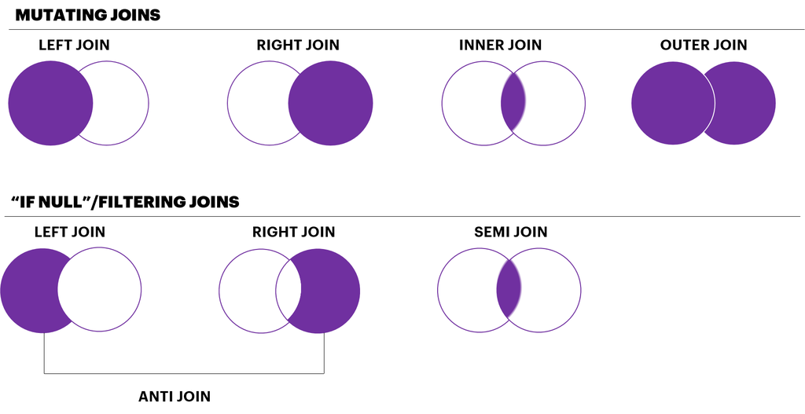

### **Check for duplicates**

```r
life_expectancy_df %>%
  group_by(Country.Name) %>%
  dplyr::summarise(count=n()) %>%
  arrange(-count)
```

| Country.Name | count |
| --- | --- |
| Afghanistan | 1 |
| Albania | 1 |
| Algeria | 1 |
| Angola | 1 |
| Antigua And Barbuda | 1 |
| Arab World | 1 |
| Argentina | 1 |
| Armenia | 1 |
| Aruba | 1 |
| Australia | 1 |

[output cut: 193 more lines]

### **Some exploration of the distribution of Life Expectancy**

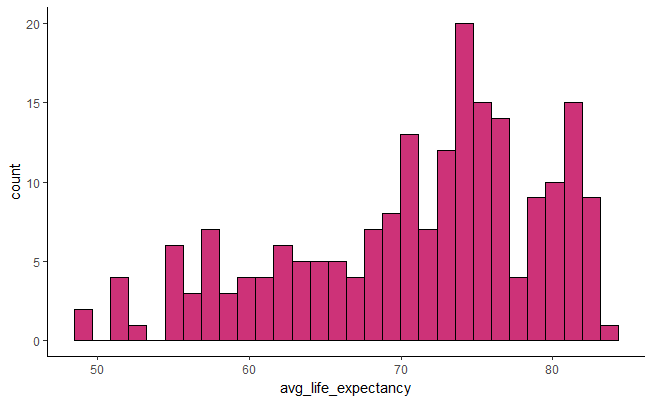

```r
ggplot(life_expectancy_df,aes(avg_life_expectancy))+
  geom_histogram(fill="violetred3",color="black")+
  theme_classic()
```

### **Let’s investigate what countries are the lower end of the life expectancy**

```r
life_expectancy_df %>%
  arrange(avg_life_expectancy)
```

| Country.Name | avg_life_expectancy |
| --- | --- |
| Central African Republic | 48.69556 |
| Sierra Leone | 49.18579 |
| Chad | 50.94249 |
| Ivory Coast | 51.22718 |
| Nigeria | 51.46034 |
| Lesotho | 51.50607 |
| Swaziland | 53.15990 |
| South Sudan | 54.44757 |
| Somalia | 54.55292 |
| Zimbabwe | 55.21565 |

[output cut: 193 more lines]

### **Let’s also visualize a** [spatial map](https://public.tableau.com/profile/rosebud.anwuri#!/vizhome/TheABC-XYZofDataScience/Sheet2?publish=yes) for Life Expectancy

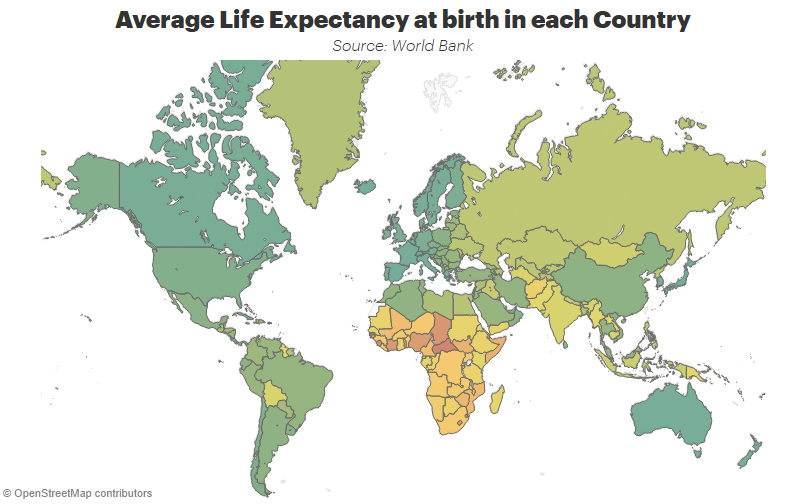

### **We want to join the holiday and the life expectancy data frames for countries that have both numbers of holidays and life expectancy. What Join will be most suitable for this?**

```r
 life_expectancy_df=life_expectancy_df %>%
    dplyr::rename(Country=Country.Name)
holiday_and_life = inner_join(holiday_df,life_expectancy_df,by="Country")
```

```
Column `Country` joining factor and character vector, coercing into character vector
```

```r
holiday_and_life
```

| Country | no_of_holidays | avg_life_expectancy |
| --- | --- | --- |
| Antigua And Barbuda | 12 | 75.53897 |
| Aruba | 10 | 75.11390 |
| Barbados | 13 | 75.08574 |
| Belize | 14 | 69.90446 |
| Canada | 10 | 81.46568 |
| Costa Rica | 9 | 78.99709 |
| Cuba | 10 | 79.09652 |
| Curacao | 11 | 76.69085 |
| Dominican Republic | 12 | 73.03142 |
| El Salvador | 14 | 72.07154 |

[output cut: 185 more lines]

### We are ready for the fun part, **Machine Learning**!

### **Let’s do some preprocessing like splitting the data into a training and test set using caret**

```r
country_data = read.csv("country_data.csv")
set.seed(1)
idx=createDataPartition(country_data$avg_life_expectancy,p=0.7,list = F)
train=country_data[idx,]
test=country_data[-idx,]
country_data
```

| Country | no_of_holidays | avg_gdp | Population | Health.expenditure..private....of.GDP. | Labor.force..total | Unemployment_Rate | Average.Democratic.Index | avg_life_expectancy |
| --- | --- | --- | --- | --- | --- | --- | --- | --- |
| Canada | 6 | 1.640000e+12 | 34379192.6 | 3.1105988 | 19015382.9 | 7.1625001 | 9.085556 | 81.46568 |
| Costa Rica | 9 | 3.980833e+10 | 4595447.7 | 2.6189820 | 2172241.4 | 7.2750001 | 8.024444 | 78.99709 |
| Cuba | 10 | 5.167728e+10 | 11330804.0 | 0.5072338 | 5245567.0 | 2.5142857 | 3.513333 | 79.09652 |
| El Salvador | 14 | 2.286923e+10 | 6055740.1 | 2.4985349 | 2607466.4 | 6.4428572 | 6.485556 | 72.07154 |
| Guatemala | 11 | 4.741469e+10 | 15057981.4 | 4.2005943 | 6145849.0 | 3.2400000 | 5.934444 | 71.89828 |
| Honduras | 11 | 1.675116e+10 | 7613724.9 | 4.5534735 | 3040557.8 | 3.7333334 | 5.923333 | 72.67192 |
| Jamaica | 11 | 1.367433e+10 | 2697270.2 | 2.4121250 | 1269043.1 | 12.2142856 | 7.315556 | 75.13375 |
| Mexico | 12 | 1.130000e+12 | 120236083.2 | 3.1835595 | 51245483.9 | 4.6500000 | 6.757778 | 76.28778 |
| Nicaragua | 9 | 9.847058e+09 | 5805263.6 | 3.1428069 | 2447517.0 | 6.1250000 | 5.494444 | 74.02587 |
| Panama | 19 | 3.571930e+10 | 3682787.0 | 2.2225795 | 1708547.9 | 5.3125000 | 7.165556 | 77.14645 |

[output cut: 135 more lines]

```r
paste("Number of Observations for train is:",nrow(train),"& Number of Observations for test is:",nrow(test))
```

```
[1] "Number of Observations for train is: 104 & Number of Observations for test is: 41"
```

### **Some inital exploration of our data**

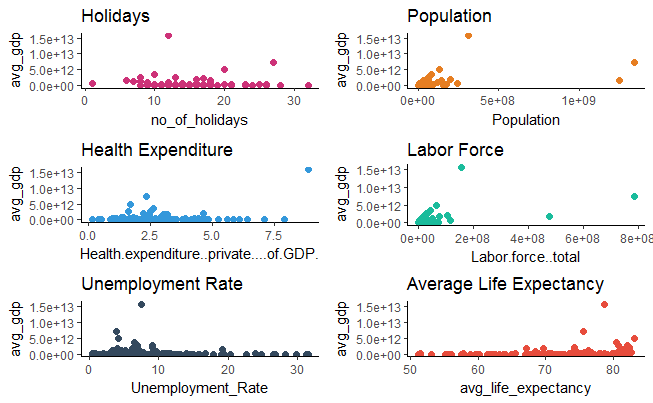

```r
p1=ggplot(country_data,aes(no_of_holidays,avg_gdp))+
  geom_point(color="violetred3",size=2)+
  ggtitle("Holidays")+
  theme_classic()
p2=ggplot(country_data,aes(Population,avg_gdp))+
  geom_point(color="#e67e22",size=2)+
  ggtitle("Population")+
  theme_classic()
p3=ggplot(country_data,aes(Health.expenditure..private....of.GDP.,avg_gdp))+
  geom_point(color="#3498db",size=2)+
  ggtitle("Health Expenditure")+
  theme_classic()
p4=ggplot(country_data,aes(Labor.force..total,avg_gdp))+
  geom_point(color="#1abc9c",size=2)+
  ggtitle("Labor Force")+
  theme_classic()
p5=ggplot(country_data,aes(Unemployment_Rate,avg_gdp))+
  geom_point(color="#34495e",size=2)+
  ggtitle("Unemployment Rate")+
  theme_classic()
p6=ggplot(country_data,aes(avg_life_expectancy,avg_gdp))+
  geom_point(color="#e74c3c",size=2)+
  ggtitle("Average Life Expectancy")+
  theme_classic()
grid.arrange(p1,p2,p3,p4,p5,p6)
```

### **Change to logarithmic scale**

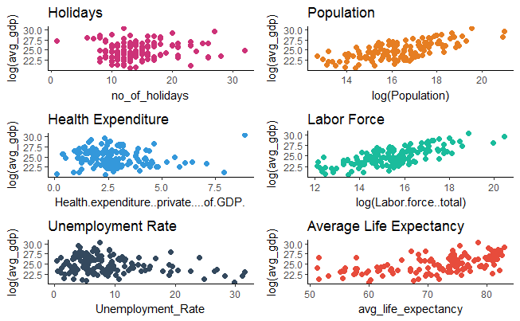

```r
p1=ggplot(country_data,aes(no_of_holidays,log(avg_gdp)))+
  geom_point(color="violetred3",size=2)+
  ggtitle("Holidays")+
  theme_classic()
p2=ggplot(country_data,aes(log(Population),log(avg_gdp)))+
  geom_point(color="#e67e22",size=2)+
  ggtitle("Population")+
  theme_classic()
p3=ggplot(country_data,aes(Health.expenditure..private....of.GDP.,log(avg_gdp)))+
  geom_point(color="#3498db",size=2)+
  ggtitle("Health Expenditure")+
  theme_classic()
p4=ggplot(country_data,aes(log(Labor.force..total),log(avg_gdp)))+
  geom_point(color="#1abc9c",size=2)+
  ggtitle("Labor Force")+
  theme_classic()
p5=ggplot(country_data,aes(Unemployment_Rate,log(avg_gdp)))+
  geom_point(color="#34495e",size=2)+
  ggtitle("Unemployment Rate")+
  theme_classic()
p6=ggplot(country_data,aes(avg_life_expectancy,log(avg_gdp)))+
  geom_point(color="#e74c3c",size=2)+
  ggtitle("Average Life Expectancy")+
  theme_classic()
grid.arrange(p1,p2,p3,p4,p5,p6)
```

### **Let’s carry out model selection**

```r
models = c("lm","rf","rpart","gbm")
set.seed(7)
model_selection = function(method_name){
  if(method_name=="rf"){
 garbage <- capture.output(

   model <-train(x= train[,c(2,4:9)], y = train[,3], method = method_name,importance=T)
   )
  }
  else{
 garbage <- capture.output(

   model <-train(x= train[,c(2,4:9)], y = train[,3], method = method_name)
   )

  }
return(model)
}
R2_metric = function(model){
  predTest=predict(model,newdata = test)
R2 = R2(predTest,test$avg_gdp)
return(c(model[["method"]],R2))
}
model_results = lapply(models,model_selection)
```

```
There were missing values in resampled performance measures.Loading required package: gbm
```

```r
models_r2 = model_results%>%
                    ldply(.,R2_metric)
names(models_r2) = c("model","r2")
models_r2 %>%
  mutate(r2=as.numeric(r2)) %>%
  arrange(-r2)
```

| model | r2 |
| --- | --- |
| rf | 0.8843197 |
| gbm | 0.7890901 |
| lm | 0.2564571 |
| rpart | 0.2548970 |

### **RandomForest did it best, let’s take a look at the important variables**

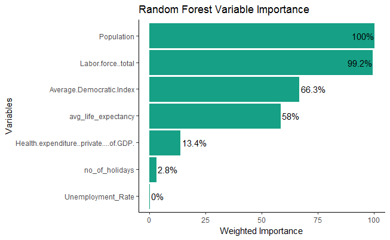

```r
varImp(model_results[[2]])[["importance"]] %>%
  as.data.frame() %>%
  mutate(variables=row.names(.)) %>%
  ggplot(.,aes(x=reorder(variables,Overall),y= Overall ))+
  geom_bar(stat = "identity",fill="#16a085",color="#16a085")+
  coord_flip()+
  theme_classic()+
  xlab("Variables")+
  ylab("Weighted Importance")+
  ggtitle("Random Forest Variable Importance")+
  geom_text(aes(label=paste0(round(Overall,1),"%"),hjust=ifelse(Overall<90,-0.1,1)))
```